# Final Group project

## 1.17 Plot Final Confusion matrix and ROC curve

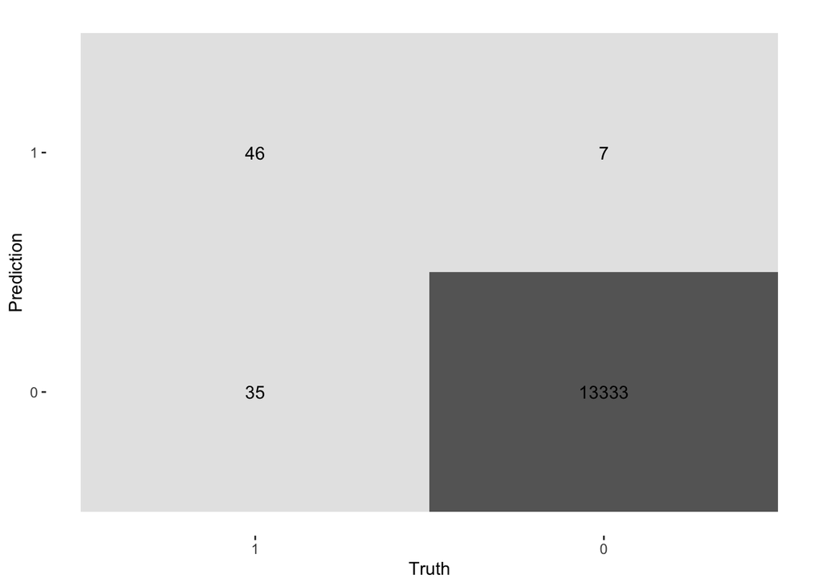

```r
## Final Confusion Matrix

last_fit_xgb %>%
  collect_predictions() %>%
  conf_mat(is_fraud, .pred_class) %>%
  autoplot(type = "heatmap")
```

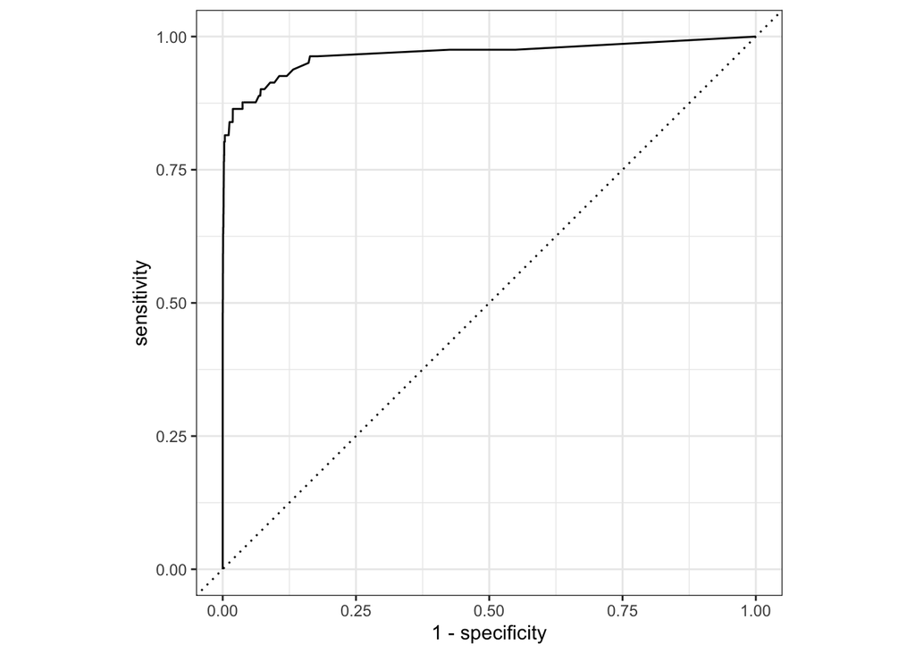

```r
## Final ROC curve
last_fit_xgb %>%
  collect_predictions() %>%
  roc_curve(is_fraud, .pred_1) %>%
  autoplot()
```

## 1.18 Calculating the cost of fraud to the company

- How much money (in US$ terms) are fraudulent transactions costing the company? Generate a table that summarizes the total amount of legitimate and fraudulent transactions per year and calculate the % of fraudulent transactions, in US$ terms. Compare your model vs the naive classification that we do not have any fraudulent transactions.

```r
# Fit the model and obtain predictions
best_model_preds <- xgb_wflow %>%
  fit(data = card_fraud_train) %>%
  augment(new_data = card_fraud)

# Compute confusion matrix
conf_matrix <- best_model_preds %>%
  conf_mat(truth = is_fraud, estimate = .pred_class)

# Select relevant columns for cost analysis
cost <- best_model_preds %>%
  select(is_fraud, amt, pred = .pred_class)

# Calculate different cost components
cost <- cost %>%
  mutate(
    false_naives = ifelse(is_fraud == 1, amt, 0),                  # Naive false: all transactions considered not fraud
    false_negatives = ifelse(pred == 0 & is_fraud == 1, amt, 0),   # False negatives: predicted not fraud, but actually fraud
    false_positives = ifelse(pred == 1 & is_fraud == 0, amt, 0),   # False positives: predicted fraud, but actually not fraud
    true_positives = ifelse(pred == 1 & is_fraud == 1, amt, 0),    # True positives: predicted fraud and actually fraud
    true_negatives = ifelse(pred == 0 & is_fraud == 0, amt, 0)     # True negatives: predicted not fraud and actually not fraud
  )

# Summarize the cost components
cost_summary <- cost %>%
  summarise(across(starts_with(c("false", "true", "amt")), ~ sum(.x, na.rm = TRUE)))

cost_summary <- cost_summary / 1000000  # Convert cost values to millions

cost_summary
```

```
##   false_naives false_negatives false_positives true_positives true_negatives
## 1     2.075089       0.4685252       0.1969789       1.606564       44.91184
##       amt
## 1 47.1839
```

```r
# Analyze cost summary
false_negatives_cost <- cost_summary$false_negatives
false_naives_cost <- cost_summary$false_naives

# Compare cost components
if (false_negatives_cost < false_naives_cost) {
  message("False negatives are costing the company less in terms of money.")
} else if (false_naives_cost < false_negatives_cost) {
  message("False naives are costing the company less in terms of money.")
} else {
  message("False negatives and false naives are costing the company the same amount.")
}
```

```
## False negatives are costing the company less in terms of money.
```

```r
# Calculate the total savings in fraud refunds
total_savings <- false_naives_cost - false_negatives_cost
message("With our model, we are saving $", total_savings, " million in fraud refunds.")
```

```
## With our model, we are saving $1.606564 million in fraud refunds.
```

- If we use a naive classifier thinking that all transactions are legitimate and not fraudulent, the cost to the company is $2.08.
- With our best model, the total cost of false negatives, namely transactions our classifier thinks are legitimate but which turned out to be fraud, is $0.47.
- Our classifier also has some false positives, $0.20, namely flagging transactions as fraudulent, but which were legitimate. Assuming the card company makes around 2% for each transaction (source: https://startups.co.uk/payment-processing/credit-card-processing-fees/), the amount of money lost due to these false positives is $0.00
- The $ improvement over the naive policy is $1.60.